# 05 Kollokasjoner

## Oppstart

### Preamble

Contains imports and some utility code.

```python
from dhlab.module_update import update, css, code_toggle
```

```python
css()
```

```python
import dhlab.graph_networkx_louvain as gnl
import dhlab.nbtext as nb
import networkx as nx
%matplotlib inline
```

```python
import warnings
warnings.filterwarnings('ignore')
```

# Kollokasjoner eller assosiasjoner

Hvilke ord opptrer et ord sammen med innenfor et korpus?

### Define a corpus

Bruk gjerne Dewey eller temaord for å definere korpuset, hold det forholdsvis lite rundt 200 bøker.

```python
korpus = nb.book_urn(ddk='641.2%', period=(1960, 2020), limit=200)
```

Kommandoen nb.frame() kan benyttes på en hel del output. Gir en fin oversikt over data, og kan brukes .head() for å se de første eksemplene.

```python
nb.frame(korpus).head(10)
```

|  | 0 | 1 | 2 | 3 |
| --- | --- | --- | --- | --- |
| 0 | 2016072948039 | Johansen, Vidar Kenneth | Spansk vin | 2005 |
| 1 | 2010041403019 | Clarke, Oz | Gyldendals vinhåndbok | 1997 |
| 2 | 2011083006031 |  | Vinreiser | 2010 |
| 3 | 2008102100096 | Johnson, Hugh | Toscana | 2000 |
| 4 | 2011063008113 |  | Aquavitguiden | 2003 |
| 5 | 2015052648126 | Vardøen, Jan | Tøffe drinker | 2006 |
| 6 | 2010062808033 | Olaf-Hansen, Erik | Drikk vin | 1995 |
| 7 | 2014102848020 | Marthinsen, Tom | Vinens vinnere 2007 | 2006 |
| 8 | 2016021507627 | Ronold, Arne | Verdt å vite om vin | 2001 |
| 9 | 2008081500018 | McCarthy, Ed | Vin for dummies | 1998 |

## Lager kollokasjoner fra korpuset

Et skrittvis eksempel.

1. Bygg kollokasjonen
2. Finn en referanse
3. Sammenlign kollokasjon med referanse

### Bygg kollokasjon

Kommandoen er `urn_coll()`. Legg gjerne inn en sjekk med konkordans.

```python
collword = 'hvitvin'
```

```python
# konkordans-sjekk

nb.urn_concordance(word = 'østers', urns = korpus, size = 5)
```

[output not shown]

Så kan vi hente ut selve kollokasjonen,dvs. ord som står innenfor en viss avstand fra målordet.

```python
coll = nb.urn_coll(collword, urns = korpus, after = 5, before = 5, limit = 1000)
```

Kollokasjonen er en såkalt **dataframe** som kan undersøkes med `.head()` som ovenfor.

```python
coll.head(10)
```

|  | 0 |
| --- | --- |
| , | 2997 |
| . | 2744 |
| og | 1917 |
| en | 1779 |
| er | 1156 |
| som | 974 |
| av | 921 |
| i | 830 |
| med | 758 |
| tørr | 723 |

## Finn referanse

Det er flere måter å sammenligne på. En er å bruke bokhylla selv om som referanse. For å hente ut ord fra bokhylla brukes kommandoen `totals(<antall ord>)`. Korpuset selv kan også benyttes, for eksempel med kommandoen `aggregate_urns(<korpusdefinisjon>)`.

#### Bokhylla aggregert

```python
tot = nb.frame(nb.totals(top = 50000))
```

```python
tot.head()
```

|  | 0 |
| --- | --- |
| . | 1265723110 |
| , | 1105303412 |
| og | 543432056 |
| i | 460246057 |
| det | 273411583 |

#### Aggregert korpus

```python
korpus_agg = nb.aggregate_urns(korpus)
```

Gjør den om til dataramme, sorterer og ser på resultatet

1. Dataramme med kommando `frame()`
2. Sortering med `frame_sort()` definert øverst i den her notebooken.

```python
korpus_agg = nb.frame_sort(nb.frame(korpus_agg))
```

```python
korpus_agg.head(10)
```

|  | 0 |
| --- | --- |
| , | 726324 |
| . | 607377 |
| og | 370316 |
| i | 284037 |
| er | 222791 |
| av | 189591 |
| som | 184028 |
| en | 155422 |
| med | 126502 |
| til | 124112 |

#### Sammenlign

Vi har nå tre frekvenslister som kan sammenlignes med hverandre. For å lette sammenlign normaliseres dem. Kommandoen for normalisering er `normalize_corpus_dataframe(<frekvensliste>)`

```python
nb.normalize_corpus_dataframe(korpus_agg)
nb.normalize_corpus_dataframe(tot)
nb.normalize_corpus_dataframe(coll)
```

```
True
```

Inspiser dataene etter normalisering

### Aggregert korpus

Fyll inn verdier for `.head()` for å se mer.

```python
korpus_agg.head()
```

|  | 0 |
| --- | --- |
| , | 0.054256 |
| . | 0.045370 |
| og | 0.027662 |
| i | 0.021217 |
| er | 0.016642 |

### Bokhylla total

```python
tot.head()
```

|  | 0 |
| --- | --- |
| . | 0.058921 |
| , | 0.051453 |
| og | 0.025297 |
| i | 0.021425 |
| det | 0.012728 |

### Kollokasjonen

```python
coll.head()
```

|  | 0 |
| --- | --- |
| , | 0.057779 |
| . | 0.052901 |
| og | 0.036958 |
| en | 0.034297 |
| er | 0.022286 |

Kollokasjonen *coll* har gjennomgående høyere verdier, noe som sannsynligvis skyldes at det er færre ord.

#### Utfør sammenligning

For sammenligning måles forskjellen på *coll* med referansen. Forskjellen måles ved å dividere hvert ords frekvens ikollokasjonen på frekvensen ordet har i referansen.

$$\textrm{assosiasjons-styrke}(w) = \frac{\textrm{coll}(w)}{\textrm{referanse}(w)}$$

Divisjonen pr.ord gjøres av Python - resultat sorteres og legges i variabelen `coll_assoc`

```python
coll_assoc = nb.frame_sort(coll**1.0/tot)
```

```python
coll_assoc.head(20)
```

|  | 0 |
| --- | --- |
| rødvin | 3778.785745 |
| tørr | 774.095565 |
| Blanc | 683.872621 |
| hvitvin | 586.722674 |
| druer | 503.036116 |
| drikkes | 443.455305 |
| druene | 437.101680 |
| fyldig | 435.095879 |
| syrlig | 362.908288 |
| Champagne | 355.738539 |
| søt | 310.695740 |
| viner | 308.125807 |
| vinene | 281.135847 |
| Bordeaux | 259.632090 |
| Frisk | 220.860154 |
| Italias | 216.024478 |
| Chateau | 210.939392 |
| sødme | 196.424334 |
| forfriskende | 193.627937 |
| Farge | 187.476420 |

### Sammenlign med korpus

Her kan det være nyttig å bruke en eksponent for å dempe effekten av lavfrekvente ord.

```python
coll_assoc_korp = nb.frame_sort(coll**1.2/korpus_agg)
```

```python
coll_assoc_korp.head(20)
```

|  | 0 |
| --- | --- |
| lagringssterk | 67.611803 |
| Forkjærlighet | 67.611803 |
| velavkjølte | 67.611803 |
| skalldyrpasta | 43.431630 |
| Fordeling | 41.214418 |
| Vilagrandes | 36.661546 |
| KAMPROP | 36.661546 |
| fiskekjøttet, | 36.661546 |
| rieslinglignende | 33.837579 |
| fangdang | 33.805902 |
| sauemelkoster | 33.805902 |
| Ottonel). | 33.805902 |
| værang | 33.805902 |
| bialo | 33.805902 |
| sausevalget | 33.805902 |
| værdikkiå | 33.805902 |
| Carcassonne. | 33.805902 |
| predikatklasse. | 33.805902 |
| Radburnds | 33.805902 |
| lettkremet | 33.805902 |

# Visualiser med en ordsky

Visualiseringen trives best med tall mellom 0 og 1, så assosiasjonene divideres på summen av dem for å få til det. Ordskyene lages med kommonandoen `cloud(<data>)`. Pass på å ikke ta med alt for mange; det kan gi feilsituasjoner.

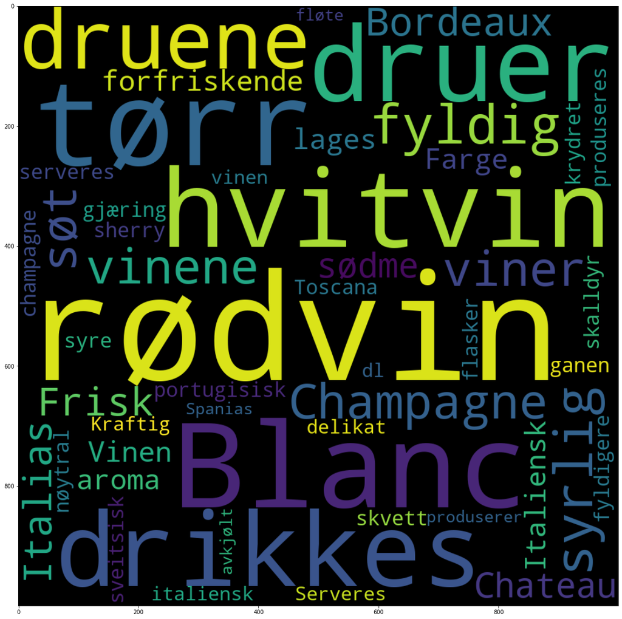

```python
nb.cloud(coll_assoc.head(50)/coll_assoc.sum())
```

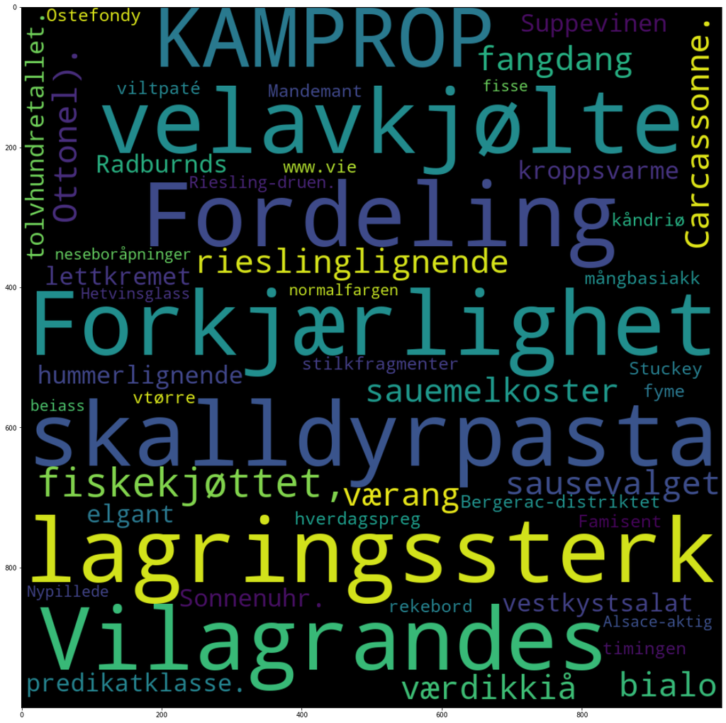

```python
nb.cloud(coll_assoc_korp.head(50)/coll_assoc_korp.sum())
```

## Hva med å dividere korpuset på totalen?

```python
korpus_ord =  nb.frame_sort(korpus_agg**1.2/tot)
```

```python
korpus_ord.head(20)
```

|  | 0 |
| --- | --- |
| vinene | 238.385637 |
| viner | 226.275816 |
| druene | 118.363541 |
| Blanc | 78.983306 |
| Chateau | 69.467129 |
| Bordeaux | 61.967194 |
| druer | 61.922495 |
| vinen | 52.667529 |
| Champagne | 45.009321 |
| aroma | 36.341231 |
| finish | 33.251016 |
| vin | 30.440402 |
| Valley | 29.639991 |
| hektar | 28.494598 |
| sødme | 28.404799 |
| drikkes | 28.361716 |
| hvitvin | 27.663750 |
| rødvin | 26.958570 |
| Vinen | 25.190839 |
| årgang | 23.018491 |

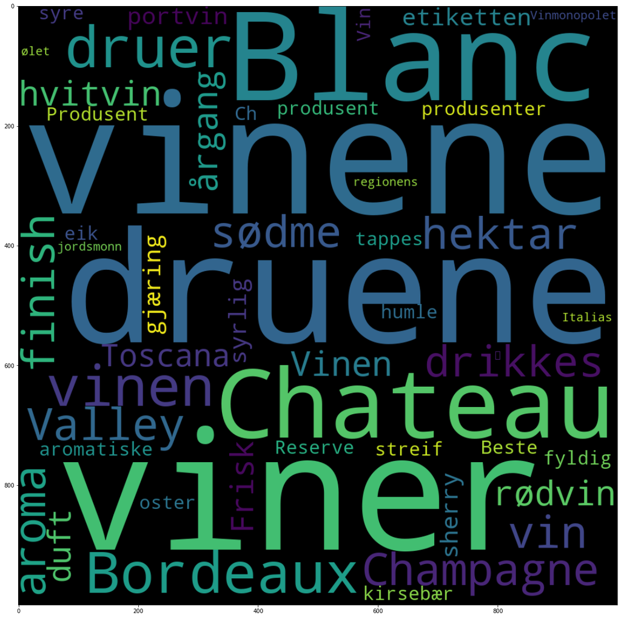

```python
nb.cloud(korpus_ord.head(50)/korpus_ord.sum())
```